# tvs comparativo

omar gonzales diaz

7/8/2019

# Principales Ecommerce del Perú - Análisis descriptivo

La idea de realizar esta investigaci�n fue conocer las estrategias de los principales ecommerece peruanos a trav�s de los productos que ofrecen en sus respectivos sitios web.

Esta es una investigaci�n descriptiva. Lo que queremos es mostrar los datos que encontramos e inferir algunos comentarios que se pueden observar. No es el objetivo de esta entrada analizar a profundidad el por qu� de cada una de las estrategias de marketing de cada empresa; por el contrario, mencionaremos algunos datos resaltantes que se observan en los 3 ecommerce m�s importantes del pa�s: Linio, Ripley y Falabella.

## Sobre los datos

Para obtener los datos ingresamos a las secci�n de televisores de los 3 ecommerce estudiados. Toda p�gina web tiene una estructura HTML que debe respestar, y con la cu�l debe ser consistente. Aprovechando estas 2 caracter�sticas es que podemos programar scripts que, en base a la estructura de cada Ecommerce recoja los siguientes datos de cada uno de los televisores publicitados: a) Marca, b) Nombre del producto, c) Precio actual y d) Precio antes.

Para este proposito se utiliz� el paquete [RSelenium](https://cran.r-project.org/web/packages/RSelenium/index.html). Este paquete utiliza el web drive [Selenium 2.0](https://seleniumhq.github.io/docs/wd.html) para automatizar la navegaci�n en un navegador web como Chrome o Firefox.

**Estos son los enlaces a las secciones de televisores de cada uno de los ecommerce estudiados:**

[Linio](https://www.linio.com.pe/c/tv-y-video/televisores)

[Falabella](http://www.falabella.com.pe/falabella-pe/category/cat1450502/Smart-TV?navAction=push)

[Ripley](http://www.ripley.com.pe/ripley-peru/tv-todas)

*Por ahora, solo colocar� el script para descargar los datos desde DropBox, y generar todos los gr�ficos. Los scripts para extraer la data directamente de los ecommerce los colocar� en las pr�ximas semanas.

## TVs por Ecommerce

Observamos que la tendencia entre los 3 ecommerce es la misma que el a�o 2016: Linio es el ecommerce con m�s televisores, seguido por Ripley, y finalmente Falabella. Los 3 ecommerce incrementaron la cantidad de TVs ofertadas este 2017, siendo Linio el ecommerce que increment� m�s esta cantidad (+140%).

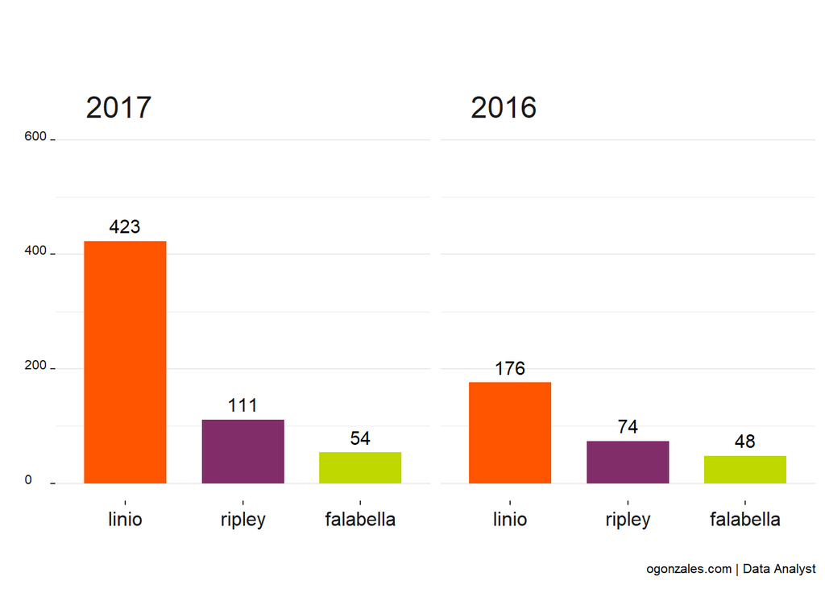

| periodo | ecommerce | cantidad | diferencia.porcentual |
| --- | --- | --- | --- |
| 2016 | falabella | 48 | 0.0000 |
| 2016 | linio | 176 | 0.0000 |
| 2016 | ripley | 74 | 0.0000 |
| 2017 | falabella | 54 | 0.1250 |
| 2017 | linio | 423 | 1.4034 |
| 2017 | ripley | 111 | 0.5000 |

## Pulgadas vs Precio

Scaterplot que muestra la tendencia entre pulgadas vs precio.

**2016:** este a�o se vio una tendencia clara en los 3 ecommerce, el l�mite en pulgadas para todos los ecomerce, de cualquier marca, era 65 pulgadas. Solo se observan 4 excepciones, 2 en falabella y 2 en linio; se trata de televisores de 75 pulgadas.

**2017:** si bien a�n parece que los 3 ecommerce optan por contar con varios Tvs de 65 pulgada, se observa una mayor oferta de TVs de mayor tama�o, principalmente de 75 y 86 pulgadas.

[interactive chart not shown]

## TVs por Rango de Precio

Es interesante observar que la variedad de televisores ofertados se encuentran entre los S/.500 y S/.1,500 soles.

Tambi�n encontramos una buena cantidad de televisores en el rango “> S/.4000”.

[interactive chart not shown]

## Distribuci�n de precios por ecommerce

Si nos fijamos en la distribuci�n de precios, notamos que Linio concentra sus precios entre los S/.890 y S/.2,299, con un promedio de S/.1,469. Existe una gran cantidad de TVs cuyos precios son considerados como *outliers*.

En Ripley sucede algo similar encontramos que los precios se centran entre los S/.1,024 y los S/.3,999, siendo el promedio: S/.1,899. As� como varios televisores con precios considerados como *outliers*.

En Falabella notamos que los precios se encuentran entre los S/.5,999 y los S/.1,699, con un promedio de S/.2,949.

Nota: en el comparativo con el a�o pasado, notamos que la cantidad de *outliers* se ha incrementado notoriamente tanto en Linio como en Ripley. Esto no sucede en Falabella que se mantiene con 3 televisores con precios considerados como *outliers*.

[interactive chart not shown]

## Variedad de marcas de TV seg�n rango de precios

### Ripley

Tambi�n que en los rangos de precios m�s elevados *de S/.2,500 a S/.3,500, de S/.3,500 a S/.4,500, y > S/.4,500* la varidad de marcas a disminuido: el 2017 ya no encontramos productos de las marcas Sharp ni Panasonic en estos rangos.

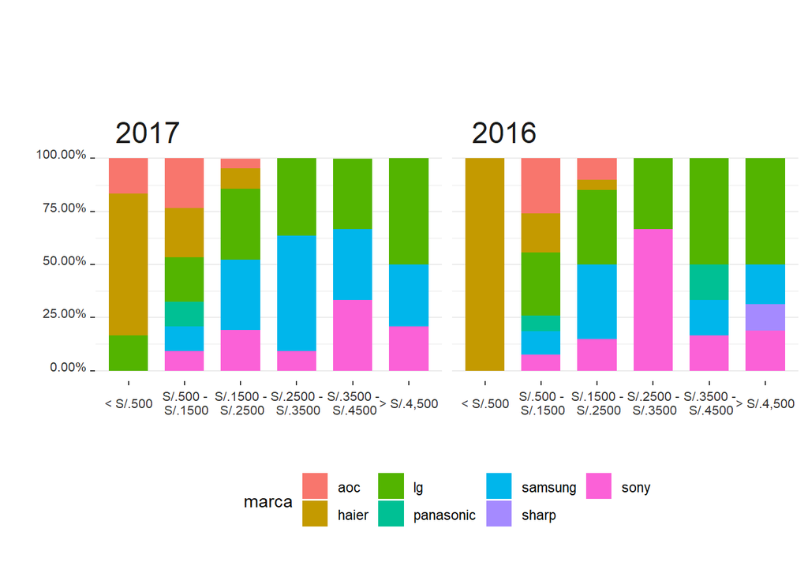

### Falabella

Falabella est� ofreciendo m�s televisores de la marca *samsung* en el rango m�s alto (“> S/.4,000”). El a�o pasado era *lg* la marca que domniba esta categor�a.

Este ecommerce no ofrece productos de menos de S/.500 soles.

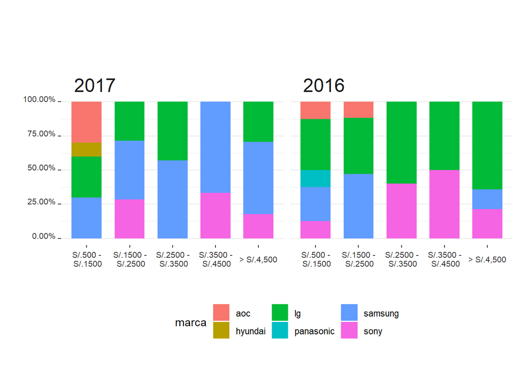

### Linio

Linio es el ecommerce con mayor variedad de marcas en cada uno de los rangos de precios.

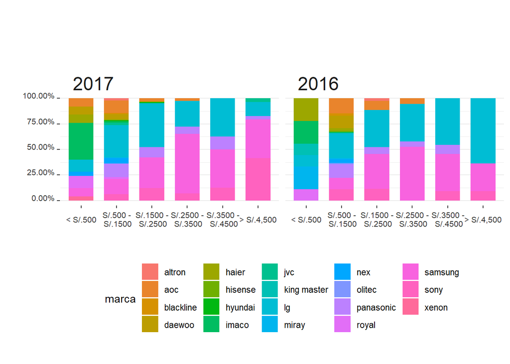

## Precio actual por marca de TV

Estos son las marcas que muestran una gran variedad de precios en los 3 ecommerce: *lg*, *samsung* y *sony*, esto podr�a deberse a la variedad de televisores tanto a nivel de tama�o como de tecnolog�a.

### Ripley: distribuci�n de precios por marca

[interactive chart not shown]

### Falabella: distribuci�n de precios por marca

[interactive chart not shown]

### Linio: distribuci�n de precios por marca (parte 1 y 2)

[interactive chart not shown]

#Conclusiones:

Me result� muy interesante el 2016, y lo volv� a confirmar este 2017, la perspectiva de negocio de Linio. Este ecommerce, nacido netamente en el espacio digital es el que m�s variedad de productos ofrece.

Este proyecto me permiti� trabajar ciertas t�cnicas de extracci�n de datos. Me pareci� s�per interesante la cantidad de datos que est�n disponibles en la web, de los cu�les podemos obtener informaci�n valiosa con las herramientas adecuadas. Lograrlo cost� un poco, pero con los librer�as de `R` esta tarea se facilit� mucho; especialmente con `RSelenium`, `Gggplot2` y `Plotly`.

Por otro lado Ripley y Falabella tienen un set de televisores a ofertar, es como si a�n en un ecommerce cuidaran el *m^2* digital.

Agradezco sus comentarios y sugerencias,

Omar G.